# Домашняя работа

#### ФИО: Коновалова Кристина

## Импорт необходимых библиотек

```python
import pandas as pd
import numpy as np
import statsmodels.api as sm
import statsmodels.stats.proportion as proportion
import matplotlib.pyplot as plt
import math
from scipy.stats import norm
```

## Задание 1

> Однажды в Самарканде турист заказывал Яндекс-такси. На десятом заказе впервые приехал таксист, который уже раньше приезжал к туристу. Для упрощения предположим, что все n таксистов Самарканда всегда на работе и приезжают равновероятно.

**а)** Построим график функции правдоподобии как функции от общего количества такси n. Найдем оценку числа n методом максимального правдоподобия.

По условию на десятом заказе приехал таксист, который уже ранее приезжал к туристу. Мы хотим найти вероятность этого события для различных значений общего количества таксистов n.

Пусть **p** представляет вероятность того, что на десятом заказе приехал таксист, который уже ранее приезжал к туристу. Тогда вероятность того, что на десятом заказе приехал новый таксист, равна **(1 - p)**.

Так как все таксисты приезжают равновероятно, вероятность, что каждый таксист не приезжал ранее: $((n-1)/n) * ((n-2)/(n-1)) * ... * ((n-9)/(n-8)) = ((n-9)/n).$

Тогда функция правдоподобия $L(n)$ будет равна произведению вероятностей, что все 9 предыдущих заказов были обслужены новыми таксистами, и на десятом заказе приехал таксист, который уже ранее приезжал к туристу:

$L(n) = ((n-9)/n) * (1 - p)$

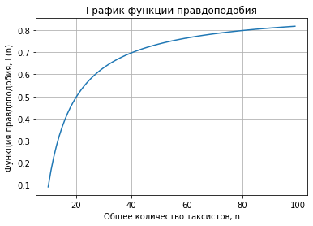

```
Оценка числа n методом максимального правдоподобия: 99
```

```python
def likelihood(n, p):
    return ((n-9)/n) * (1 - p)

# Пусть вероятность приезда таксиста, который уже ранее приезжал к туристу = 0.1
p = 0.1

n_values = np.arange(10, 100, 1)

likelihood_values = [likelihood(n, p) for n in n_values]


plt.plot(n_values, likelihood_values)
plt.xlabel('Общее количество таксистов, n')
plt.ylabel('Функция правдоподобия, L(n)')
plt.title('График функции правдоподобия')
plt.grid(True)
plt.show()

# Нахождение оценки числа n методом максимального правдоподобия
estimated_n = n_values[np.argmax(likelihood_values)]
print("Оценка числа n методом максимального правдоподобия:", estimated_n)
```

Возьмем производную функции $L(n) = ((n-9)/n) * (1 - p)$ и приравняем ее к нулю:

$dL/dn = 0$

Производная функции **L(n)** будет равна:

$dL/dn = (9 - 18/n - p) / (n^2)$

$(9 - 18/n - p) / (n^2) = 0$

$9n - 18 - pn = 0$

$9n = 18 + pn$

$n = (18 + pn) / 9 $

**б)** Используя геометрическое распределение, определим вероятность того, что повторный приезд таксиста произойдет на конкретном заказе. Вероятность этого равна **(1/n)**, где **n** - количество таксистов.

Математическое ожидание для геометрического распределения выразим следующим образом:

$E(X) = 1/p$, где **p** - вероятность "успеха" (вероятность повторного приезда таксиста на каждом заказе).

Мы знаем, что $p = 1/n $ Подставляя это значение в формулу для математического ожидания, получаем:

$E(X) = 1 / (1/n) = n$

Таким образом, математическое ожидание номера заказа, на котором происходит первый повторный приезд, является просто значением общего количества такси n.

То есть, математическое ожидание равно самому количеству такси n.

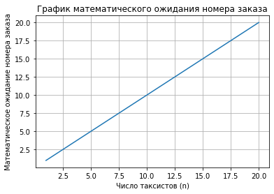

```python
import numpy as np
import matplotlib.pyplot as plt

# Пусть максимальное число таксистов для построения графика = 20
n_max = 20

n_values = np.arange(1, n_max + 1)
p = 1 / n_values
E = 1 / p

plt.plot(n_values, E)
plt.xlabel('Число таксистов (n)')
plt.ylabel('Математическое ожидание номера заказа')
plt.title('График математического ожидания номера заказа')
plt.grid(True)
plt.show()
```

Для оценки числа n таксистов методом моментов,предположим, что у нас есть выборка размера **N**, где **N** - количество заказов. Обозначим среднее значение выборки как **X̄**.

В данном случае мы знаем, что математическое ожидание номера заказа, на котором происходит первый повторный приезд таксиста, равно $1/p$, где $p = 1/n$.

Следовательно, математическое ожидание выборки равно:

**E(X̄) = 1/p**.

Мы можем приблизить математическое ожидание выборки с помощью среднего значения выборки:

**E(X̄) ≈ X̄ = 1/p**.

Отсюда можно выразить оценку $p$ :

**p ≈ 1/X̄**.

Поскольку $p = 1/n$, мы можем получить оценку числа таксистов n:

**n ≈ 1/(1/X̄) = X̄**.

Таким образом, оценка числа n таксистов методом моментов будет равна среднему значению выборки.

**в)**

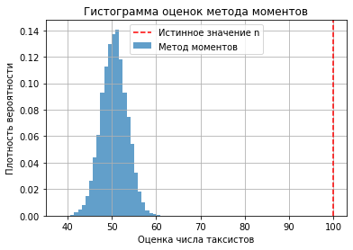

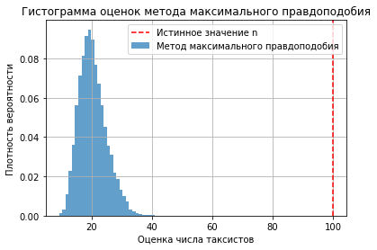

```python
true_n = 100

# Зададим количество симуляций и размер выборки
num_simulations = 10000
sample_size = 100


moment_estimates = np.zeros(num_simulations)
mle_estimates = np.zeros(num_simulations)


for i in range(num_simulations):
    # Генерируем выборку с повторениями
    sample = np.random.choice(range(1, true_n+1), size=sample_size, replace=True)

    # Рассчитываем оценку методом моментов
    moment_estimates[i] = np.mean(sample)

    # Рассчитываем оценку методом максимального правдоподобия
    mle_estimates[i] = sample_size / np.sum(1 / sample)

# Строим гистограмму для оценок метода моментов
plt.hist(moment_estimates, bins=30, density=True, alpha=0.7, label='Метод моментов')
plt.axvline(x=true_n, color='r', linestyle='--', label='Истинное значение n')
plt.xlabel('Оценка числа таксистов')
plt.ylabel('Плотность вероятности')
plt.title('Гистограмма оценок метода моментов')
plt.legend()
plt.grid(True)
plt.show()

# Строим гистограмму для оценок метода максимального правдоподобия
plt.hist(mle_estimates, bins=30, density=True, alpha=0.7, label='Метод максимального правдоподобия')
plt.axvline(x=true_n, color='r', linestyle='--', label='Истинное значение n')
plt.xlabel('Оценка числа таксистов')
plt.ylabel('Плотность вероятности')
plt.title('Гистограмма оценок метода максимального правдоподобия')
plt.legend()
plt.grid(True)
plt.show()
```

**Оценим смещение, дисперсию и среднеквадратичную ошибку двух методов:**

```python
def compute_metrics(estimated_values, true_value):

    bias = np.mean(estimated_values) - true_value
    variance = np.var(estimated_values)
    mse = np.mean((estimated_values - true_value)**2)

    return bias, variance, mse


# Вычисляем метрики для оценок метода моментов
moment_bias, moment_variance, moment_mse = compute_metrics(moment_estimates, true_n)

# Вычисляем метрики для оценок метода максимального правдоподобия
mle_bias, mle_variance, mle_mse = compute_metrics(mle_estimates, true_n)

print('Метод моментов:')
print('Смещение:', moment_bias)
print('Дисперсия:', moment_variance)
print('Среднеквадратичная ошибка:', moment_mse)
print()
print('Метод максимального правдоподобия:')
print('Смещение:', mle_bias)
print('Дисперсия:', mle_variance)
print('Среднеквадратичная ошибка:', mle_mse)
```

```
Метод моментов:
Смещение: -49.497997
Дисперсия: 8.266729797991
Среднеквадратичная ошибка: 2458.31843681

Метод максимального правдоподобия:
Смещение: -79.68690076041548
Дисперсия: 20.493116746603643
Среднеквадратичная ошибка: 6370.495269546909
```

## Задание 2

> Однажды в Самарканде турист заказывал Яндекс-такси. На десятом заказе он обнаружил, что у таксистов было 6 разных имён. Для упрощения предположим, что все n имён среди таксистов встречаются равновероятно и независимо от поездки к поездке.

**a)** Для расчета функции правдоподобия используем биномиальное распределение, так как у нас есть бинарное событие (появление конкретного имени) с фиксированной вероятностью успеха (вероятность появления конкретного имени).

Пусть **p** - вероятность появления конкретного имени среди таксистов, а **k** - количество разных имен среди 10 заказов. Тогда функция правдоподобия будет выглядеть следующим образом:

$L(n) = (nCk) * p^k * (1-p)^{(n-k)}$ , где **(nCk)** - биномиальный коэффициент "n по k", $ nCk= n! / (k! * (n-k)!)$

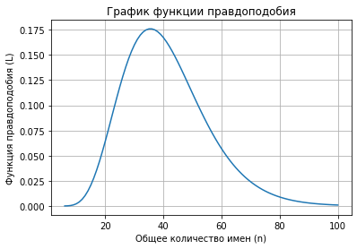

```python
def likelihood_function(n, k, p):
    coefficient = math.comb(n, k)
    likelihood = coefficient * (p ** k) * ((1 - p) ** (n - k))
    return likelihood

k = 6  # количество разных имен
p = 1 / k  # вероятность появления конкретного имени

n_values = range(k, 101)  # от k до 100
likelihood_values = [likelihood_function(n, k, p) for n in n_values]


plt.plot(n_values, likelihood_values)
plt.xlabel('Общее количество имен (n)')
plt.ylabel('Функция правдоподобия (L)')
plt.title('График функции правдоподобия')
plt.grid(True)
plt.show()
```

Для нахождения оценки числа **n** методом максимального правдоподобия, мы должны найти значение **n**, при котором функция правдоподобия достигает максимума. В данном случае, у нас есть фиксированное количество разных имен **k = 6**, и мы хотим найти оптимальное значение **n**.

$L(n) = (nCk) * p^k * (1-p)^{(n-k)}$

Максимизируем функциию правдоподобия:

$lnL(n) = ln((nCk)) + k * ln(p) + (n-k) * ln(1-p)$

```python
from scipy.special import comb
from scipy.optimize import minimize_scalar

def ln_L(n):
    return np.log(comb(n, 6)) + 6 * np.log(1/n) + 4 * np.log((n-1)/n)

# Максимизируем log-likelihood функцию
result = minimize_scalar(lambda n: -ln_L(n), method='bounded', bounds=(6, 100))

estimated_n = result.x

print("Оценка числа n методом максимального правдоподобия:", estimated_n)
```

```
Оценка числа n методом максимального правдоподобия: 99.99999226946096
```

**б)**

Пусть n обозначает общее количество возможных имен, а X обозначает случайную величину, равную числу разных имён среди 10 таксистов.  
Вероятность того, что определенное имя появится у одного таксиста, равна 1/n. Значит, вероятность того, что данное имя не появится у одного таксиста, равна (1 - 1/n). Вероятность того, что данное имя не появится ни у одного из 10 таксистов, равна ((1 - 1/n)^10), так как эти события независимы.

Тогда вероятность того, что хотя бы одно имя из n возможных появится среди 10 таксистов, равна 1 минус вероятность того, что ни одно имя не появится:  
P(X >= 1) = 1 - ((1 - 1/n)^10)

Математическое ожидание числа разных имён можно выразить как:  
E(X) = n *P(X >= 1) = n* (1 - ((1 - 1/n)^10))

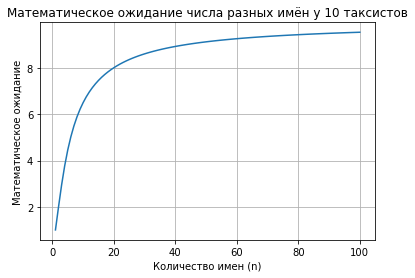

```python
def expected_num_of_names(n):
    return n * (1 - ((1 - 1/n)**10))

n_values = np.arange(1, 101)

expected_values = [expected_num_of_names(n) for n in n_values]

plt.plot(n_values, expected_values)
plt.xlabel('Количество имен (n)')
plt.ylabel('Математическое ожидание')
plt.title('Математическое ожидание числа разных имён у 10 таксистов')
plt.grid(True)
plt.show()
```

Для оценки числа n методом моментов нам нужно использовать информацию о выборочных моментах и приравнять их к теоретическим моментам.  
У нас есть информация о 10 заказах и том, что было обнаружено 6 разных имен. Мы можем использовать это для оценки параметра n.

Выборочный момент k-го порядка определяется следующим образом:

M_k = (1/N) * ∑(x_i^k) , где N - размер выборки (в данном случае 10), x_i - значение выборки (количество разных имен).

Теоретический момент k-го порядка в данной задаче равен:

m_k = n * (1 - ((1 - 1/n)^10))^k

Моменты первого порядка равны:

M_1 = (1/10) *(6^1) = 0.6 m_1 = n* (1 - ((1 - 1/n)^10))^1

Приравнивая выборочный и теоретический моменты первого порядка, получим:

0.6 = n * (1 - ((1 - 1/n)^10))^1

Решим это уравнение относительно n численно. Воспользуемся библиотекой scipy.optimize для поиска решения:

```python
from scipy.optimize import fsolve

def moment_equation(n):
    return n * (1 - ((1 - 1/n)**10)) - 0.6

initial_guess = 10
estimated_n = fsolve(moment_equation, initial_guess)

print("Оценка числа n методом моментов:", estimated_n[0])
```

```
Оценка числа n методом моментов: 0.6076526071648419
```

**в)**

> Предположим, что настоящее n равно 20. Проведя 10000 симуляций десяти вызовов такси, рассчитайте 10000 оценок методом моментов и 10000 оценок методом максимального правдоподобия. Постройте гистограммы для оценок двух методов. Оцените смещение, дисперсию и среднеквадратичную ошибку двух методов. если по выборке в симуляциях оценка метода моментов или метода максимального правдоподобия стремится к бесконечности и, строго говоря, не существует, то можно ограничить её сверху большим числом, например, 100.

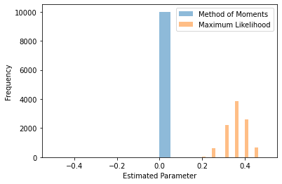

```python
np.random.seed(42)

n_simulations = 10000
n = 20
true_param = n

method_of_moments_estimates = []
maximum_likelihood_estimates = []

for _ in range(n_simulations):
    taxi_names = np.random.choice(range(1, n+1), size=10, replace=True)

    # Оценка методом моментов
    moments_estimate = len(set(taxi_names)) / (1 + np.mean(1 / np.bincount(taxi_names)))
    method_of_moments_estimates.append(min(moments_estimate, 100))
    # Оценка методом максимального правдоподобия
    likelihood_estimate = -np.log(1 - 1 / n) * (len(set(taxi_names)) - 1)
    maximum_likelihood_estimates.append(min(likelihood_estimate, 100))


# Построение гистограмм оценок методом моментов и методом максимального правдоподобия
plt.hist(method_of_moments_estimates, bins=20, alpha=0.5, label='Method of Moments')
plt.hist(maximum_likelihood_estimates, bins=20, alpha=0.5, label='Maximum Likelihood')
plt.xlabel('Estimated Parameter')
plt.ylabel('Frequency')
plt.legend()
plt.show()
```

## Задача №3

> Иноагент Иннокентий по 20 наблюдениям строит 95%-й доверительный интервал для математического ожидания несколькими способами: классический асимптотический нормальный интервал, с помощью наивного бутстрэпа, с помощью бутстрэпа t-статистики

**a)** 1.Классический асимптотический нормальный интервал:

```python
np.random.seed(42)
sample_size = 20
n_simulations = 10000
samples = np.random.exponential(scale=1, size=(n_simulations, sample_size))

sample_means = np.mean(samples, axis=1)
sample_std = np.std(samples, axis=1, ddof=1)

# Построение доверительного интервала
z_score = norm.ppf(0.975)  # 1.96 для 95%-го доверительного интервала
lower_bound = sample_means - z_score * (sample_std / np.sqrt(sample_size))
upper_bound = sample_means + z_score * (sample_std / np.sqrt(sample_size))

# Проверка накрытия истинного математического ожидания
true_mean = 1
coverage = np.mean((lower_bound <= true_mean) & (upper_bound >= true_mean))
print("Вероятность накрытия истинного математического ожидания:", coverage)
```

```
Вероятность накрытия истинного математического ожидания: 0.9036
```

2.Наивный бутстрэп:

```python
np.random.seed(42)
sample_size = 20
n_simulations = 10000
samples = np.random.exponential(scale=1, size=(n_simulations, sample_size))

sample_means = np.mean(samples, axis=1)


bootstrap_means = []
for i in range(n_simulations):
    bootstrap_sample = np.random.choice(sample_means, size=sample_size, replace=True)
    bootstrap_mean = np.mean(bootstrap_sample)
    bootstrap_means.append(bootstrap_mean)


lower_bound = np.percentile(bootstrap_means, 2.5)
upper_bound = np.percentile(bootstrap_means, 97.5)

true_mean = 1
coverage = np.mean((lower_bound <= true_mean) & (upper_bound >= true_mean))
print("Вероятность накрытия истинного математического ожидания:", coverage)
```

```
Вероятность накрытия истинного математического ожидания: 1.0
```

3.Бутстрэп t-статистики:

```python
import numpy as np
from scipy.stats import t

np.random.seed(42)
sample_size = 20
n_simulations = 10000
samples = np.random.exponential(scale=1, size=(n_simulations, sample_size))

sample_means = np.mean(samples, axis=1)
sample_std = np.std(samples, axis=1, ddof=1)

bootstrap_means = []
for i in range(n_simulations):
    bootstrap_sample = np.random.choice(samples[i], size=sample_size, replace=True)
    bootstrap_mean = np.mean(bootstrap_sample)
    bootstrap_means.append(bootstrap_mean)


se = np.std(bootstrap_means, ddof=1)

t_score = t.ppf(0.975, df=sample_size-1)
lower_bound = np.mean(sample_means) - t_score * se
upper_bound = np.mean(sample_means) + t_score * se

true_mean = 1
coverage = np.mean((lower_bound <= true_mean) & (upper_bound >= true_mean))
print("Вероятность накрытия истинного математического ожидания:", coverage)
```

```
Вероятность накрытия истинного математического ожидания: 1.0
```

**б)** 1.Классический асимптотический нормальный интервал:

```python
import numpy as np
from scipy.stats import t


np.random.seed(42)
sample_size = 20
n_simulations = 10000
samples = np.random.standard_t(df=3, size=(n_simulations, sample_size))

# Оценка среднего значения и стандартного отклонения
sample_means = np.mean(samples, axis=1)
sample_std = np.std(samples, axis=1, ddof=1)

# Построение доверительного интервала
t_score = t.ppf(0.975, df=sample_size-1)
lower_bound = sample_means - t_score * (sample_std / np.sqrt(sample_size))
upper_bound = sample_means + t_score * (sample_std / np.sqrt(sample_size))

# Проверка накрытия истинного математического ожидания
true_mean = 1
coverage = np.mean((lower_bound <= true_mean) & (upper_bound >= true_mean))
print("Вероятность накрытия истинного математического ожидания:", coverage)
```

```
Вероятность накрытия истинного математического ожидания: 0.2196
```

2.Наивный бутстрэп:

```python
import numpy as np
from scipy.stats import t


np.random.seed(42)
sample_size = 20
n_simulations = 10000
samples = np.random.standard_t(df=3, size=(n_simulations, sample_size))

# Оценка среднего значения
sample_means = np.mean(samples, axis=1)

# Бутстрэп
bootstrap_means = []
for i in range(n_simulations):
    bootstrap_sample = np.random.choice(sample_means, size=sample_size, replace=True)
    bootstrap_mean = np.mean(bootstrap_sample)
    bootstrap_means.append(bootstrap_mean)

# Построение доверительного интервала
lower_bound = np.percentile(bootstrap_means, 2.5)
upper_bound = np.percentile(bootstrap_means, 97.5)

# Проверка накрытия истинного математического ожидания
true_mean = 1
coverage = np.mean((lower_bound <= true_mean) & (upper_bound >= true_mean))
print("Вероятность накрытия истинного математического ожидания:", coverage)
```

```
Вероятность накрытия истинного математического ожидания: 0.0
```

3.Бутстрэп t-статистики:

```python
import numpy as np
from scipy.stats import t


np.random.seed(42)
sample_size = 20
n_simulations = 10000
samples = np.random.standard_t(df=3, size=(n_simulations, sample_size))

# Оценка среднего значения и стандартного отклонения
sample_means = np.mean(samples, axis=1)
sample_std = np.std(samples, axis=1, ddof=1)

# Бутстрэп
bootstrap_means = []
for i in range(n_simulations):
    bootstrap_sample = np.random.choice(samples[i], size=sample_size, replace=True)
    bootstrap_mean = np.mean(bootstrap_sample)
    bootstrap_means.append(bootstrap_mean)

# Оценка стандартной ошибки среднего значения
se = np.std(bootstrap_means, ddof=1)

# Построим доверительный интервал
t_score = t.ppf(0.975, df=sample_size-1)
lower_bound = np.mean(sample_means) - t_score * se
upper_bound = np.mean(sample_means) + t_score * se


true_mean = 1
coverage = np.mean((lower_bound <= true_mean) & (upper_bound >= true_mean))
print("Вероятность накрытия истинного математического ожидания:", coverage)
```

```
Вероятность накрытия истинного математического ожидания: 1.0
```

**в)** Вероятность накрытия истинного математического ожидания с помощью **бутстрэпа t-статистики** равна 1.0. Это указывает на то, что этот способ более точно оценивает доверительный интервал для математического ожидания, гарантируя, что интервалы, построенные с помощью бутстрэпа t-статистики, включают истинное математическое ожидание с высокой степенью уверенности.Таким образом, можно сказать, что этот способ является наиболее точным и лучшим в данной задаче.

## Задание 4

> Проверьте гипотезу о том, что ожидаемые результаты экзамена по теории вероятностей тех, у кого фамилия начинается с гласной буквы и с согласной буквы, равны. В качестве альтернативной гипотезы возьмите гипотезу о неравенстве.

##### Для заданий 4-6 подгрузим таблицу с оценками студентов:

```python
df=pd.read_excel('Оценки за экзамен.xlsx')
df
```

|  | Фамилия | ИО | Оценка |
| --- | --- | --- | --- |
| 0 | Репенкова | Полина Александровна | 16.0 |
| 1 | Ролдугина | Софья Александровна | 0.0 |
| 2 | Сафина | Алия Линаровна | 19.0 |
| 3 | Сидоров | Иван Максимович | 26.0 |
| 4 | Солоухин | Иван Владимирович | 21.0 |
| ... | ... | ... | ... |
| 327 | Сенников | Александр - | 19.0 |
| 328 | Ся | Юйцянь - | 0.0 |
| 329 | Сятова | Альфия - | 0.0 |
| 330 | Темиркулов | Дастан Автандилович | 0.0 |
| 331 | Эшмеев | Павел Владиславович | NaN |

332 rows × 3 columns

```python
#Заменим значения NaN на 0 и преобразуем столбец "Оценка" в числовой формат

if df['Оценка'].isnull().any():
    df['Оценка'].fillna(0, inplace=True)

df['Оценка'] = pd.to_numeric(df['Оценка'])
```

**Сформулируем нулевую и альтернативную гипотезу:**

H0: Ожидаемые результаты экзамена по теории вероятностей одинаковы для двух групп (μ1 = μ2)  
H1: Ожидаемые результаты экзамена по теории вероятностей различаются для двух групп (μ1 ≠ μ2)

```python
#Создадим выбороки для студентов с гласной и согласной начальной буквой фамилии:
vowel_group = df[df['Фамилия'].str[0].str.upper().isin(['А', 'У', 'О', 'Ы', 'И', 'Э', 'Я', 'Ю', 'Ё', 'Е'])]['Оценка']
consonant_group = df[~df['Фамилия'].str[0].str.upper().isin(['А', 'У', 'О', 'Ы', 'И', 'Э', 'Я', 'Ю', 'Ё', 'Е'])]['Оценка']
```

**а) тест Уэлча**

```python
t_stat, p_value = stats.ttest_ind(vowel_group, consonant_group, equal_var=False)
print('t-статистика:', t_stat)
print('p-значение:', p_value)
```

```
t-статистика: -1.0778460863139139
p-значение: 0.28521021475980995
```

**Вывод:** При уровне значимости α = 0.05, нет оснований отвергать нулевую гипотезу, так как полученное p-значение (0.285) больше уровня значимости. Следовательно, что мы не можем сделать вывод о статистически значимом различии в ожидаемых результатах экзамена между студентами с фамилиями, начинающимися на гласную и согласную букву.

**б)Наивный бутстрэп**

```python
np.random.seed(42)
n_iterations = 10000

diff_means = np.zeros(n_iterations)

for i in range(n_iterations):

    bootstrap_vowel = np.random.choice(vowel_group, size=len(vowel_group), replace=True)
    bootstrap_consonant = np.random.choice(consonant_group, size=len(consonant_group), replace=True)
    diff_means[i] = np.mean(bootstrap_vowel) - np.mean(bootstrap_consonant)

obs_diff_mean = np.mean(vowel_group) - np.mean(consonant_group)
p_value = np.sum(diff_means >= obs_diff_mean) / n_iterations

print('p-значение:', p_value)
```

```
p-значение: 0.5038
```

**вывод:** нет оснований отвергать нулевую гипотезу

**в)бутстрэп t-статистики**

```python
np.random.seed(42)
obs_t_stat = np.abs(np.mean(vowel_group) - np.mean(consonant_group)) / np.sqrt((np.var(vowel_group) / len(vowel_group)) + (np.var(consonant_group) / len(consonant_group)))
n_iterations = 10000

bootstrap_t_stats = np.zeros(n_iterations)

for i in range(n_iterations):

    bootstrap_vowel = np.random.choice(vowel_group, size=len(vowel_group), replace=True)
    bootstrap_consonant = np.random.choice(consonant_group, size=len(consonant_group), replace=True)

    bootstrap_t_stat = np.abs(np.mean(bootstrap_vowel) - np.mean(bootstrap_consonant)) / np.sqrt((np.var(bootstrap_vowel) / len(bootstrap_vowel)) + (np.var(bootstrap_consonant) / len(bootstrap_consonant)))
    bootstrap_t_stats[i] = bootstrap_t_stat


p_value = (np.sum(bootstrap_t_stats >= obs_t_stat) + np.sum(bootstrap_t_stats <= -obs_t_stat)) / n_iterations

print('p-значение:', p_value)
```

```
p-значение: 0.5161
```

**вывод:** нет оснований отвергать нулевую гипотезу

**г)перестановочный тест**

```python
np.random.seed(42)
obs_stat = np.mean(vowel_group) - np.mean(consonant_group)

n_permutations = 10000

perm_stats = np.zeros(n_permutations)


for i in range(n_permutations):

    combined = np.concatenate([vowel_group, consonant_group])
    permuted = np.random.permutation(combined)

    perm_vowel_group = permuted[:len(vowel_group)]
    perm_consonant_group = permuted[len(vowel_group):]

    perm_stat = np.mean(perm_vowel_group) - np.mean(perm_consonant_group)

    perm_stats[i] = perm_stat

p_value = (np.abs(perm_stats) >= np.abs(obs_stat)).mean()

print('p-значение:', p_value)
```

```
p-значение: 0.2609
```

**Вывод:** нет оснований отвергать нулевую гипотезу

# Задание №5

> Составьте таблицу сопряжённости, поделив студентов писавших экзамен на четыре группы по двум признакам: набрал ли больше медианы или нет, на согласную или гласную букву начинается фамилия.

Разделим студентов писавших экзамен на четыре группы по двум признакам: набрал ли больше медианы или нет, на согласную или гласную букву начинается фамилия.

```python
def get_first_letter_type(last_name):
    vowels = ['а', 'е', 'ё', 'и', 'о', 'у', 'ы', 'э', 'ю', 'я']
    if last_name[0].lower() in vowels:
        return 'гласная'
    else:
        return 'согласная'

median_score = df['Оценка'].median()


# Функция для определения, набрал ли студент больше медианы
def is_above_median(score):
    if score > median_score:
        return 'больше медианы'
    else:
        return 'меньше или равно медиане'


df['Тип первой буквы'] = df['Фамилия'].apply(get_first_letter_type)
df['Медиана'] = df['Оценка'].apply(is_above_median)

# Создандим таблицу сопряжённости
contingency_table = pd.crosstab(df['Медиана'], df['Тип первой буквы'])
print(contingency_table)
```

```
Тип первой буквы          гласная  согласная
Медиана
больше медианы                 21        145
меньше или равно медиане       28        138
```

###### а)Постройте 95% асимптотический интервал для отношения шансов хорошо написать экзамен («несогласных» к «согласным»).Проверьте гипотезу о том, что отношение шансов равно 1 и укажите P-значение

Пусть  
-Количество "несогласных" студентов: НЕсог= 49  
-Количество "согласных" студентов: сог = 283  
-Количество "несогласных" студентов, которые хорошо написали экзамен: НЕсог_хор = 21  
-Количество "согласных" студентов, которые хорошо написали экзамен: сог_хор = 145

тогда построим 95% асимптотический интервал для отношения шансов хорошо написать экзамен:

```python
НЕсог= 49
сог = 283
НЕсог_хор = 21
сог_хор = 145

# Вычислим отношения шансов
odds_ratio = (НЕсог_хор / (НЕсог - НЕсог_хор)) / (сог_хор / (сог - сог_хор))

# Построим асимптотический интервал для отношения шансов
se = np.sqrt(1 / НЕсог_хор + 1 / (НЕсог - НЕсог_хор) + 1 / сог_хор + 1 / (сог - сог_хор))
lower = np.exp(np.log(odds_ratio) - 1.96 * se)
upper = np.exp(np.log(odds_ratio) + 1.96 * se)

print("95% Асимптотический интервал для отношения шансов:")
print("Нижняя граница:",lower)
print("Верхняя граница",upper)
```

```
95% Асимптотический интервал для отношения шансов:
Нижняя граница: 0.3870902431823096
Верхняя граница 1.3162320763800788
```

вывод: 95% асимптотический интервал для отношения шансов хорошо написать экзамен: от 0.387 до 1.316

##### Проверка гипотезы о равенстве отношения шансов 1

НО:отношение шансов равно 1  
Н1:отношение шансов не равно 1

```python
from scipy.stats import fisher_exact

oddsratio, p_value = fisher_exact(contingency_table)

print("Отношение шансов:", oddsratio)
print("P-значение:", p_value)
```

```
Отношение шансов: 0.7137931034482758
P-значение: 0.3533108749219954
```

вывод: нет оснований отвергать Н0

**б)**  
Доля успеха в группе "Больше медианы" и "Согласная буква": p1 = 145/ (145 + 138)  
Доля успеха в группе "Меньше медианы" и "Согласная буква": p2 = 138 / (145 + 138)  
Доля успеха в группе "Больше медианы" и "Гласная буква": p3 = 21 / (21 + 28)  
Доля успеха в группе "Меньше медианы" и "Гласная буква": p4 = 28 / (21 + 28)

```python
A = 145
B = 138
C = 21
D = 28
```

```python
def calculate_interval(A, B, C, D):
    p1 = A / (A + B)
    p2 = B / (A + B)
    p3 = C / (C + D)
    p4 = D / (C + D)
    p = (p1 / p2) / (p3 / p4)

    se = math.sqrt((1 / (A + B)) + (1 / (C + D)) + (1 / (A + C)) + (1 / (B + D)))

    lower = math.exp(math.log(p) - 1.96 * se)
    upper = math.exp(math.log(p) + 1.96 * se)

    return (lower, upper)

interval = calculate_interval(A, B, C, D)
print("95% асимптотический интервал:", interval)
```

```
95% асимптотический интервал: (0.9659244265063416, 2.0319459718181965)
```

Для проверки гипотезы о том, что отношение вероятностей равно 1 используем Хи-квадрат тест.

H0: Отношение вероятностей равно 1.  
H1: Отношение вероятностей не равно 1.

```python
from scipy.stats import chi2_contingency

def test_hypothesis(A, B, C, D):
    observed = [[A, B], [C, D]]
    chi2, p_value, _, _ = chi2_contingency(observed)
    return p_value

p_value = test_hypothesis(A, B, C, D)
print("P-значение:", p_value)
```

```
P-значение: 0.35320687726026134
```

вывод: нет оснований отвергать Н0

**в)** Построим 95% интервал для отношения шансов хорошо написать экзамен с помощью наивного бутстрэпа

```python
всего = 166
НЕсог_хор = 21
сог_хор = 145
bootstrap_size = 1000

odds_ratios = np.zeros(bootstrap_size)


for i in range(bootstrap_size):
    НЕсог_хор_ = np.random.binomial(всего, (НЕсог_хор / всего))
    сог_хор_  = np.random.binomial(всего, (сог_хор /всего))

    # Рассчитываем отношение шансов для бутстрэп-выборки
    odds_ratio = (НЕсог_хор_ / сог_хор_)
    odds_ratios[i] = odds_ratio

# Рассчитываем 95% интервал
lower = np.percentile(odds_ratios, 2.5)
upper = np.percentile(odds_ratios, 97.5)


# Вывод результатов
print("95% Интервал для отношения шансов:", (lower, upper))
```

```
95% Интервал для отношения шансов: (0.08842043574186431, 0.2013786549021448)
```

Гипотезы:  
H0: Отношение шансов равно 1 (нет разницы между "несогласными" и "согласными" студентами)  
H1: Отношение шансов не равно 1 (есть разница между "несогласными" и "согласными" студентами)  
Для проверки гипотезы используем тест Фишера:

```python
from scipy.stats import fisher_exact

oddsratio, p_value = fisher_exact(contingency_table)

print("Отношение шансов:", oddsratio)
print("P-значение:", p_value)
```

```
Отношение шансов: 0.7137931034482758
P-значение: 0.3533108749219954
```

вывод: нет оснований отвергать Н0